# Clustering Assignment Preprocessing

rsantos3

3/30/2020

This is a substantial exercise. The MNIST dataset is a dataset of 60,000 training and 10,000 test examples of handwritten digits, originally constructed by Yann Lecun, Corinna Cortes, and Christopher J.C. Burges. It is very widely used to check simple methods. There are 10 classes in total (“0” to “9”). This dataset has been extensively studied, and there is a history of methods and feature constructions at https://en.wikipedia.org/wiki/MNIST database and at http://yann.lecun.com/exdb/mnist/. You should notice that the best methods perform extremely well. The original dataset is at http://yann.lecun.com/ exdb/mnist/. It is stored in an unusual format, described in detail on that website. Writing your own reader is pretty simple, but web search yields readers for standard packages. There is reader code in Matlab available (at least) at http://ufldl.stanford.edu/wiki/index.php/Using the MNIST Dataset. There is reader code for R available (at least) at https://stackoverflow.com/questions/ 21521571/how-to-read-mnist-database-in-r.

The dataset consists of 28 × 28 images. These were originally binary images, but appear to be grey level images as a result of some anti-aliasing. I will ignore mid grey pixels (there aren’t many of them) and call dark pixels “ink pixels,” and light pixels “paper pixels.” The digit has been centered in the image by centering the center of gravity of the image pixels. For this exercise, we will use raw pixels in untouched images.

```r
library(BBmisc)
library(readr)
library(caret)
library(e1071)
library(ggplot2)
library(randomForest)
library(EBImage)
library(hash)
```

```r
# Data Preprocessing
to.read_train = file("train-images-idx3-ubyte", "rb")
to.read_trail_labels <- file("train-labels-idx1-ubyte", "rb")
data_info <- readBin(to.read_train, integer(), n=4, endian = "big")
label_info <- readBin(to.read_trail_labels, integer(), n=2, endian = "big")
num_train <- data_info[2]
in_m <- as.numeric(readBin(to.read_train, integer(), size = 1, n=28*28*num_train, endian = "big", signed = FALSE))
mat <- matrix(in_m, nrow = num_train, ncol = 28*28, byrow = TRUE)
lab <- as.integer(readBin(to.read_trail_labels, raw(), n=num_train, endian = "big",
                          signed = FALSE))

train <- as.data.frame(mat)
train$labels <- lab
train$labels <- as.factor(train$labels)

to.read_test = file("t10k-images-idx3-ubyte", "rb")
to.read_test_labels <- file("t10k-labels-idx1-ubyte", "rb")
data_info <- readBin(to.read_test, integer(), n=4, endian = "big")
label_info <- readBin(to.read_test_labels, integer(), n=2, endian = "big")
num_test <- data_info[2]
in_m <- readBin(to.read_test, integer(), size = 1, n=28*28*num_test, endian = "big", signed = FALSE)
mat <- matrix(in_m, nrow = num_test, ncol = 28*28, byrow = TRUE)
lab <- as.integer(readBin(to.read_test_labels, raw(), n=num_test, endian = "big",
                          signed = FALSE))

test <- as.data.frame(mat)
test$labels <- lab
test$labels <- as.factor(test$labels)

write_csv(train, "MNIST_Train.csv")
write_csv(test, "MNIST_Test.csv")
```

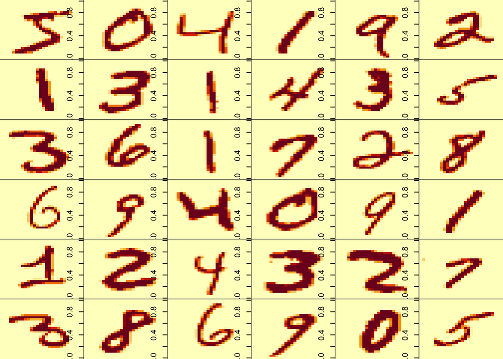

```r
to.read_train = file("train-images-idx3-ubyte", "rb")
to.read_trail_labels <- file("train-labels-idx1-ubyte", "rb")
data_info <- readBin(to.read_train, integer(), n=4, endian = "big")
label_info <- readBin(to.read_trail_labels, integer(), n=2, endian = "big")

num_train <- data_info[2]

# Output the image files
par(mfrow = c(6,6))
par(mar = c(0,0,0,0))
for (i in 1:36) {m <- matrix(readBin(to.read_train, integer(), size=1, n=28*28, endian = "big", signed = FALSE), 28, 28); image(m[, 28:1])}
```